# Empleo y Género

Maria Florencia Aguilera y Rocío Ospitaleche

## Introducción

En el presente informe se utilizan datos sobre empleo- desempleo y género provenientes del Banco Mundial. Se analizan variables relacionadas con la participación de mujeres y hombres en el empleo en distintas ramas de actividad, desempleo, autoempleo, empleadores, trabajo doméstico no remunerado. También incluye el dato de la existencia o no en algunos países de legislación contra el acoso sexual en el ámbito laboral. Los datos existentes en la tabla original corresponden a algunos países de Latinoamérica, el Caribe, España y a nivel mundial, para los años que van desde 1970 hasta 2018 (aunque no hay datos de todos los países ni de todos los años). A partir de estos datos nos haremos preguntas que permitan visualizar las brechas de genero que existen en el empleo y formular posibles hipótesis al respecto, entendiendo que al ser una base de datos construida en términos binarios (varones/mujeres) obtendremos respuestas acotadas a dicha población y no generalizables al conjunto, al no encontrarse representadas otras identidades de género existentes.

Fuente de los datos: Extraídos y traducidos del sitio web del [Banco Mundial](https://databank.worldbank.org/source/gender-statistics).

## Exploración de los datos

Para leer los datos utilizamos la función “read_csv” y los asignamos a la variable “empleo_genero”:

```r
empleo_genero <- read_csv("datos/empleo_genero.csv")
```

Para ordenar los datos de la tabla utilizamos la función “pivot_longer”. De esta forma, los datos de los años que aparecían como nombres de distintas columnas se agrupan dentro de una sola columna bajo el nombre “Anio”. Y asignamos la nueva tabla a la variable “empleo_genero_largo”

```r
empleo_genero_largo <- pivot_longer(empleo_genero,
                                    cols=4:52,
                                    names_to = "Anio",
                                    values_to = "Valor")
```

```r
empleo_genero_largo
```

```
## # A tibble: 22,540 × 5
##    variable            pais_region codigo_pais_region Anio  Valor
##    <chr>               <chr>       <chr>              <chr> <dbl>
##  1 empleadoras_mujeres Argentina   ARG                1970     NA
##  2 empleadoras_mujeres Argentina   ARG                1971     NA
##  3 empleadoras_mujeres Argentina   ARG                1972     NA
##  4 empleadoras_mujeres Argentina   ARG                1973     NA
##  5 empleadoras_mujeres Argentina   ARG                1974     NA
##  6 empleadoras_mujeres Argentina   ARG                1975     NA
##  7 empleadoras_mujeres Argentina   ARG                1976     NA
##  8 empleadoras_mujeres Argentina   ARG                1977     NA
##  9 empleadoras_mujeres Argentina   ARG                1978     NA
## 10 empleadoras_mujeres Argentina   ARG                1979     NA
## # … with 22,530 more rows
```

Si bien en las primeras 10 filas podemos obervar que no existen datos en la columna “valor” (NA) esto se debe a que el set de datos original no cuenta con datos para los primeros 20 años. Sin embargo, esto no afectará nuestro trabajo ya que tomaremos en cuenta las variables y datos correspondientes a los últimos 20 años que si tienen valores válidos.

Luego utilizamos la función “pivot_wider” para reordenar las variables que aparecían en la primera columna bajo la etiqueta “variable” y las ubicamos en distintas columnas. Y asignamos la nueva tabla a la variable “empleo_genero_ordenado”, que es con la que vamos a trabajar.

```r
empleo_genero_ordenado <- pivot_wider(empleo_genero_largo,
                                      names_from = variable,
                                      values_from = Valor)|>
                          mutate(Anio=as.numeric(Anio))
```

```r
empleo_genero_ordenado
```

```
## # A tibble: 1,127 × 23
##    pais_region codigo_pais_region  Anio empleadoras_mujeres empleadores_hombres
##    <chr>       <chr>              <dbl>               <dbl>               <dbl>
##  1 Argentina   ARG                 1970                  NA                  NA
##  2 Argentina   ARG                 1971                  NA                  NA
##  3 Argentina   ARG                 1972                  NA                  NA
##  4 Argentina   ARG                 1973                  NA                  NA
##  5 Argentina   ARG                 1974                  NA                  NA
##  6 Argentina   ARG                 1975                  NA                  NA
##  7 Argentina   ARG                 1976                  NA                  NA
##  8 Argentina   ARG                 1977                  NA                  NA
##  9 Argentina   ARG                 1978                  NA                  NA
## 10 Argentina   ARG                 1979                  NA                  NA
## # … with 1,117 more rows, and 18 more variables:
## #   empleo_agricultura_mujeres <dbl>, empleo_agricultura_hombres <dbl>,
## #   empleo_industria_mujeres <dbl>, empleo_industria_hombres <dbl>,
## #   empleo_servicios_mujeres <dbl>, empleo_servicios_hombres <dbl>,
## #   empleo_informal_mujeres <dbl>, empleo_informal_hombres <dbl>,
## #   legislacion_acoso_sexual <dbl>, autoempleo_mujeres <dbl>,
## #   autoempleo_hombres <dbl>, empleo_parcial_mujeres <dbl>, …
```

Para contar la cantidad de variables y de casos que hay en la tabla utilizamos la siguiente función:

```r
glimpse(empleo_genero_ordenado)
```

```
## Rows: 1,127
## Columns: 23
## $ pais_region                             <chr> "Argentina", "Argentina", "Arg…
## $ codigo_pais_region                      <chr> "ARG", "ARG", "ARG", "ARG", "A…
## $ Anio                                    <dbl> 1970, 1971, 1972, 1973, 1974, …
## $ empleadoras_mujeres                     <dbl> NA, NA, NA, NA, NA, NA, NA, NA…
## $ empleadores_hombres                     <dbl> NA, NA, NA, NA, NA, NA, NA, NA…
## $ empleo_agricultura_mujeres              <dbl> NA, NA, NA, NA, NA, NA, NA, NA…
## $ empleo_agricultura_hombres              <dbl> NA, NA, NA, NA, NA, NA, NA, NA…
## $ empleo_industria_mujeres                <dbl> NA, NA, NA, NA, NA, NA, NA, NA…
## $ empleo_industria_hombres                <dbl> NA, NA, NA, NA, NA, NA, NA, NA…
## $ empleo_servicios_mujeres                <dbl> NA, NA, NA, NA, NA, NA, NA, NA…
## $ empleo_servicios_hombres                <dbl> NA, NA, NA, NA, NA, NA, NA, NA…
## $ empleo_informal_mujeres                 <dbl> NA, NA, NA, NA, NA, NA, NA, NA…
## $ empleo_informal_hombres                 <dbl> NA, NA, NA, NA, NA, NA, NA, NA…
## $ legislacion_acoso_sexual                <dbl> NA, NA, NA, NA, NA, NA, NA, NA…
## $ autoempleo_mujeres                      <dbl> NA, NA, NA, NA, NA, NA, NA, NA…
## $ autoempleo_hombres                      <dbl> NA, NA, NA, NA, NA, NA, NA, NA…
## $ empleo_parcial_mujeres                  <dbl> NA, NA, NA, NA, NA, NA, NA, NA…
## $ desempleo_educacion_mujeres             <dbl> NA, NA, NA, NA, NA, NA, NA, NA…
## $ desempleo_educacion_hombres             <dbl> NA, NA, NA, NA, NA, NA, NA, NA…
## $ desempleo_mujeres                       <dbl> NA, NA, NA, NA, NA, NA, NA, NA…
## $ desempleo_hombres                       <dbl> NA, NA, NA, NA, NA, NA, NA, NA…
## $ trabajo_domestico_no_remunerado_mujeres <dbl> NA, NA, NA, NA, NA, NA, NA, NA…
## $ trabajo_domestico_no_remunerado_hombres <dbl> NA, NA, NA, NA, NA, NA, NA, NA…
```

Una vez ordenados los datos, la tabla tiene 1127 observaciones y 23 variables.

Seleccionamos los datos de los países latinoamericanos y del Caribe y excluimos los datos etiquetados como “España”, “Latin America & Caribbean” y “Mundo” y los agrupamos por año (Anio). Para eso, utilizamos la función “filter” y “group_by:

```r
empleo_genero_ordenado|> filter(pais_region !="Latin America & Caribbean" & pais_region != "Mundo" & pais_region != "EspaÃ±a")|>
                      group_by(Anio)
```

```
## # A tibble: 1,029 × 23
## # Groups:   Anio [49]
##    pais_region codigo_pais_region  Anio empleadoras_mujeres empleadores_hombres
##    <chr>       <chr>              <dbl>               <dbl>               <dbl>
##  1 Argentina   ARG                 1970                  NA                  NA
##  2 Argentina   ARG                 1971                  NA                  NA
##  3 Argentina   ARG                 1972                  NA                  NA
##  4 Argentina   ARG                 1973                  NA                  NA
##  5 Argentina   ARG                 1974                  NA                  NA
##  6 Argentina   ARG                 1975                  NA                  NA
##  7 Argentina   ARG                 1976                  NA                  NA
##  8 Argentina   ARG                 1977                  NA                  NA
##  9 Argentina   ARG                 1978                  NA                  NA
## 10 Argentina   ARG                 1979                  NA                  NA
## # … with 1,019 more rows, and 18 more variables:
## #   empleo_agricultura_mujeres <dbl>, empleo_agricultura_hombres <dbl>,
## #   empleo_industria_mujeres <dbl>, empleo_industria_hombres <dbl>,
## #   empleo_servicios_mujeres <dbl>, empleo_servicios_hombres <dbl>,
## #   empleo_informal_mujeres <dbl>, empleo_informal_hombres <dbl>,
## #   legislacion_acoso_sexual <dbl>, autoempleo_mujeres <dbl>,
## #   autoempleo_hombres <dbl>, empleo_parcial_mujeres <dbl>, …
```

Podemos ver que, si agrupamos los datos por año, hay 49 grupos.

Hacemos la misma operación pero filtrando por “pais_region”:

```r
empleo_genero_ordenado|> filter(pais_region !="Latin America & Caribbean" & pais_region != "Mundo" & pais_region != "EspaÃ±a")|>
                      group_by(pais_region)
```

```
## # A tibble: 1,029 × 23
## # Groups:   pais_region [21]
##    pais_region codigo_pais_region  Anio empleadoras_mujeres empleadores_hombres
##    <chr>       <chr>              <dbl>               <dbl>               <dbl>
##  1 Argentina   ARG                 1970                  NA                  NA
##  2 Argentina   ARG                 1971                  NA                  NA
##  3 Argentina   ARG                 1972                  NA                  NA
##  4 Argentina   ARG                 1973                  NA                  NA
##  5 Argentina   ARG                 1974                  NA                  NA
##  6 Argentina   ARG                 1975                  NA                  NA
##  7 Argentina   ARG                 1976                  NA                  NA
##  8 Argentina   ARG                 1977                  NA                  NA
##  9 Argentina   ARG                 1978                  NA                  NA
## 10 Argentina   ARG                 1979                  NA                  NA
## # … with 1,019 more rows, and 18 more variables:
## #   empleo_agricultura_mujeres <dbl>, empleo_agricultura_hombres <dbl>,
## #   empleo_industria_mujeres <dbl>, empleo_industria_hombres <dbl>,
## #   empleo_servicios_mujeres <dbl>, empleo_servicios_hombres <dbl>,
## #   empleo_informal_mujeres <dbl>, empleo_informal_hombres <dbl>,
## #   legislacion_acoso_sexual <dbl>, autoempleo_mujeres <dbl>,
## #   autoempleo_hombres <dbl>, empleo_parcial_mujeres <dbl>, …
```

Podemos ver que si agrupamos por países, hay 21 grupos.

A continuación seleccionamos algunas variables para calcular su valor medio, desvío estándard y rango. Elegimos calcular estos datos para el año 2018 (usando la función “filter”)

### Variables:

#### * Porcentaje de mujeres con rol de empleadoras, dentro del total de la fuerza laboral femenina (Año 2018)

```r
empleo_genero_ordenado|> filter(pais_region !="Latin America & Caribbean" & pais_region != "Mundo" & pais_region != "EspaÃ±a" & Anio == 2018)|>
                    summarise(empleadoras_promedio = mean(empleadoras_mujeres),
                              empleadoras_sd = sd(empleadoras_mujeres),
                              empleadoras_min = min(empleadoras_mujeres),
                              empleadoras_max = max(empleadoras_mujeres))
```

```
## # A tibble: 1 × 4
##   empleadoras_promedio empleadoras_sd empleadoras_min empleadoras_max
##                  <dbl>          <dbl>           <dbl>           <dbl>
## 1                 2.42           1.02           0.720            5.72
```

#### * Porcentaje de hombres con rol de empleadores, dentro del total de la fuerza laboral masculina (Año 2018)

```r
empleo_genero_ordenado|> filter(pais_region !="Latin America & Caribbean" & pais_region != "Mundo" & pais_region != "EspaÃ±a" & Anio == 2018)|>
                    summarise(empleadores_promedio = mean(empleadores_hombres),
                              empleadores_sd = sd(empleadores_hombres),
                              empleadores_min = min(empleadores_hombres),
                              empleadores_max = max(empleadores_hombres))
```

```
## # A tibble: 1 × 4
##   empleadores_promedio empleadores_sd empleadores_min empleadores_max
##                  <dbl>          <dbl>           <dbl>           <dbl>
## 1                 5.35           2.65            1.62            15.0
```

- En los países de América Latina y el Caribe en el año 2018, el promedio del porcentaje de mujeres dentro de la fuerza laboral femenina que tienen rol de empleadoras es de 2,41, con un desvío estándar de 1,02 (valor máx: 5,72 y valor mín: 0,72). Mientras que el promedio del porcentaje de hombres dentro de la fuerza laboral masculina con rol de empleadores es de 5,34 con un desvío estándar de 2,64 (valor máx: 14,96 y valor mín: 1,62).

#### * Porcentaje de mujeres trabajadoras por cuenta propia, dentro del total de la fuerza laboral femenina (Año 2018)

```r
empleo_genero_ordenado|> filter(pais_region !="Latin America & Caribbean" & pais_region != "Mundo" & pais_region != "EspaÃ±a" & Anio == 2018)|>
                summarise(autoempleo_mujeres_prom = mean(autoempleo_mujeres),
                          autoempleo_mujeres_sd = sd(autoempleo_mujeres),
                          autoempleo_mujeres_min = min(autoempleo_mujeres),
                          autoempleo_mujeres_max = max(autoempleo_mujeres))
```

```
## # A tibble: 1 × 4
##   autoempleo_mujeres_prom autoempleo_mujeres_… autoempleo_muje… autoempleo_muje…
##                     <dbl>                <dbl>            <dbl>            <dbl>
## 1                    30.0                 16.4             5.49             84.9
```

#### * Porcentaje de hombres trabajadores por cuenta propia, dentro del total de la fuerza laboral masculina (Año 2018)

```r
empleo_genero_ordenado|> filter(pais_region !="Latin America & Caribbean" & pais_region != "Mundo" & pais_region != "EspaÃ±a" & Anio == 2018)|>
                summarise(autoempleo_hombres_prom = mean(autoempleo_hombres),
                          autoempleo_hombres_sd = sd(autoempleo_hombres),
                          autoempleo_hombres_min = min(autoempleo_hombres),
                          autoempleo_hombres_max = max(autoempleo_hombres))
```

```
## # A tibble: 1 × 4
##   autoempleo_hombres_prom autoempleo_hombres_… autoempleo_homb… autoempleo_homb…
##                     <dbl>                <dbl>            <dbl>            <dbl>
## 1                    30.6                 15.2             8.38             81.0
```

- En los países de América Latina y el Caribe en el año 2018, el promedio del porcentaje de mujeres dentro de la fuerza laboral femenina trabajadoras por cuenta propia es de 30,00 con un desvío estándar de 16,40 (valor máx: 84,92 y valor mín: 5,49). Mientras que el promedio del porcentaje de hombres dentro de la fuerza laboral masculina trabajadores por cuenta propia es de 30,61 con un desvío estándar de 15,24 (valor máx: 80,95 y valor mín: 8,38).

Cabe mencionar que luego de la exploracion de los datos definimos trabajar con nuevas variables para construir las hipotesis: nos concentraremos ahora en conocer la insercion laboral diferenciada por genero en el Mercosur observando el sector industrial y de servicios.

### Hipótesis

-Existe una segmentacion horizontal en el mercado de trabajo de los paises del Mercosur por la cual las mujeres acceden en menor medida a empleos en la industria y en mayor medida en el sector servicios.

-¿Se acortó esta brecha de acceso a empleos en la industria en los ultimos 20 años?

A continuación, nos proponemos responder y graficar algunas de las preguntas formuladas y llegar a una conclusión a traves del analisis de los datos.

### Hipótesis 1

- Existe una segmentacion horizontal en el mercado de trabajo en los paises del mercosur por la cual las mujeres acceden en menor medida a empleos en la industria y en mayor medida a empleos en servicios.

-Para responder esta pregunta comenzamos filtrando los datos existentes para las variables a analizar, en los paises del mercosur dentro de los años que van de 1998 en adelante.

```r
empleo_mercosur <- select(empleo_genero_ordenado, pais_region, Anio, empleo_industria_mujeres, empleo_industria_hombres, empleo_servicios_mujeres, empleo_servicios_hombres) |>
  filter(pais_region %in% c("Argentina", "Uruguay", "Paraguay", "Brasil", "Venezuela", "Bolivia" ))|>
  filter (Anio >= 1998)
```

-Luego ordenamos la tabla, filtramos los datos disponibles para 2018 y graficamos como se comportan las variables en los distintos paises en dicho año.

```r
industria_2018 <- select(empleo_mercosur, pais_region, Anio, empleo_industria_mujeres, empleo_industria_hombres)|>
  filter(pais_region %in% c("Argentina", "Uruguay", "Paraguay", "Brasil", "Venezuela", "Bolivia" ))|>
  filter(Anio == 2018) |>
  pivot_longer(cols =c("empleo_industria_hombres","empleo_industria_mujeres"),
               names_to = "industria_x_genero",
               values_to = "valor")
```

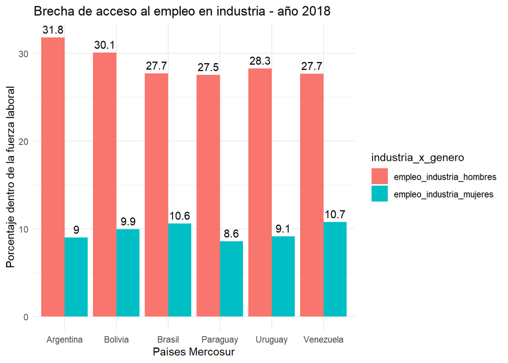

```r
ggplot(industria_2018, aes(x=pais_region,y=valor, fill=industria_x_genero))+
  geom_col(position = "dodge") +
  ggtitle ("Brecha de acceso al empleo en industria - año 2018") +
  labs(x = "Paises Mercosur",y = "Porcentaje dentro de la fuerza laboral") +
  geom_text(aes(label = round(valor, digits = 1)),
    position = position_dodge(0.9),
    vjust = -0.5)+
  theme_minimal()
```

```r
servicios_2018 <- select(empleo_mercosur, pais_region, Anio, empleo_servicios_mujeres, empleo_servicios_hombres)|>
  filter(pais_region %in% c("Argentina", "Uruguay", "Paraguay", "Brasil", "Venezuela", "Bolivia" ))|>
  filter(Anio == 2018) |>
  pivot_longer(cols =c("empleo_servicios_hombres","empleo_servicios_mujeres"),
               names_to = "servicios_x_genero",
               values_to = "valor")
```

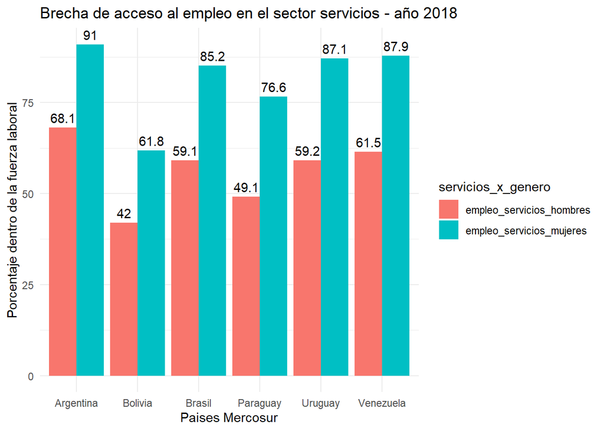

```r
ggplot(servicios_2018, aes(x=pais_region,y=valor, fill=servicios_x_genero))+
  geom_col(position = "dodge") +
  ggtitle ("Brecha de acceso al empleo en el sector servicios - año 2018") +
  labs(x = "Paises Mercosur",y = "Porcentaje dentro de la fuerza laboral") +
  geom_text(aes(label = round(valor, digits = 1)),
    position = position_dodge(0.9),
    vjust = -0.5)+
  theme_minimal()
```

### Hipotesis 2

- ¿Se vio un incremento del peso de la industria como sector empleador de la fuerza laboral de mujeres en los ultimos 20 años en los paises del Mercosur?

Para contestar nuestra segunda pregunta queremos ver especificamente que sucede en los años de los extremos con respecto a la variable que mide el porcentaje de mujeres que son empleadas en la industria y en servicios, dentro del total de la fuerza de trabajo de mujeres del pais. El objetivo es poder comparar el comportamiento de dicha variable entre los años 1998 y 2018 y luego graficar la variacion durante todos los años para verificar si hubo una reduccion o ampliacion del acceso al empleo industrial y de servicios por parte de mujeres y por lo tanto confirmar si el fenomeno que afirmamos en la hipotesis anterior se sostuvo, disminuyo o se profundizo.

-Comenzaremos calculando la variacion entre puntas para ambos sectores con el fin de verificar si es negativa o positiva.

```r
variacion_industria_mujeres <- select(empleo_genero, variable, pais_region, "1998", "2018")|>
  filter(pais_region %in% c("Argentina", "Uruguay", "Paraguay", "Brasil", "Venezuela", "Bolivia" )) |>
  filter(variable == "empleo_industria_mujeres")|>
  mutate(variacion =`2018`-`1998`)
```

```r
variacion_industria_mujeres %>%
  group_by(pais_region) %>%
  gt(caption = "Porcentaje de la fuerza laboral femenina empleada en el sector industrial") %>%
  tab_header(title = "Variación entre 1998 y 2018") %>%
  cols_label(variacion = "Variación en p.p", variable = "Variable por País") %>%
  fmt_number(columns = variacion, decimals = 1, dec_mark = ",")
```

Porcentaje de la fuerza laboral femenina empleada en el sector industrial

Variación entre 1998 y 2018

| Variable por País | 1998 | 2018 | Variación en p.p |
| --- | --- | --- | --- |
| Argentina |  |  |  |
| empleo_industria_mujeres | 10.770 | 8.975 | −1,8 |
| Bolivia |  |  |  |
| empleo_industria_mujeres | 11.273 | 9.938 | −1,3 |
| Brasil |  |  |  |
| empleo_industria_mujeres | 13.694 | 10.577 | −3,1 |
| Uruguay |  |  |  |
| empleo_industria_mujeres | 12.977 | 9.113 | −3,9 |
| Venezuela |  |  |  |
| empleo_industria_mujeres | 13.346 | 10.746 | −2,6 |
| Paraguay |  |  |  |
| empleo_industria_mujeres | 10.347 | 8.579 | −1,8 |

```r
variacion_servicios_mujeres <- select(empleo_genero, variable, pais_region, "1998", "2018")|>
  filter(pais_region %in% c("Argentina", "Uruguay", "Paraguay", "Brasil", "Venezuela", "Bolivia" )) |>
  filter(variable == "empleo_servicios_mujeres")|>
  mutate(variacion =`2018`-`1998`)
```

```r
variacion_servicios_mujeres %>%
  group_by(pais_region) %>%
  gt(caption = "Porcentaje de la fuerza laboral femenina empleada en el sector servicios") %>%
  tab_header(title = "Variación entre 1998 y 2018") %>%
  cols_label(variacion = "Variación en p.p", variable = "Variable por País") %>%
  fmt_number(columns = variacion, decimals = 1, dec_mark = ",")
```

Porcentaje de la fuerza laboral femenina empleada en el sector servicios

Variación entre 1998 y 2018

| Variable por País | 1998 | 2018 | Variación en p.p |
| --- | --- | --- | --- |
| Argentina |  |  |  |
| empleo_servicios_mujeres | 89.000 | 91.010 | 2,0 |
| Bolivia |  |  |  |
| empleo_servicios_mujeres | 48.797 | 61.811 | 13,0 |
| Brasil |  |  |  |
| empleo_servicios_mujeres | 73.456 | 85.193 | 11,7 |
| Uruguay |  |  |  |
| empleo_servicios_mujeres | 81.648 | 87.084 | 5,4 |
| Venezuela |  |  |  |
| empleo_servicios_mujeres | 85.299 | 87.941 | 2,6 |
| Paraguay |  |  |  |
| empleo_servicios_mujeres | 69.530 | 76.612 | 7,1 |

Como podemos ver en ambas tablas, la variación es negativa en el caso del acceso de mujeres al empleo en la industria y positiva en el caso del acceso al sector servicios es decir que el fenomeno descripto anteriormente se profundizó.

## Presentación grafica de la variación

A continuacion presentaremos graficamente la variacion entre puntas y la variacion en toda la serie para exponer la evolucion a lo largo del tiempo

```r
industria_1998_2018 <- select(empleo_mercosur, pais_region, Anio, empleo_industria_mujeres)|>
  filter(Anio == 1998 | Anio == 2018)
```

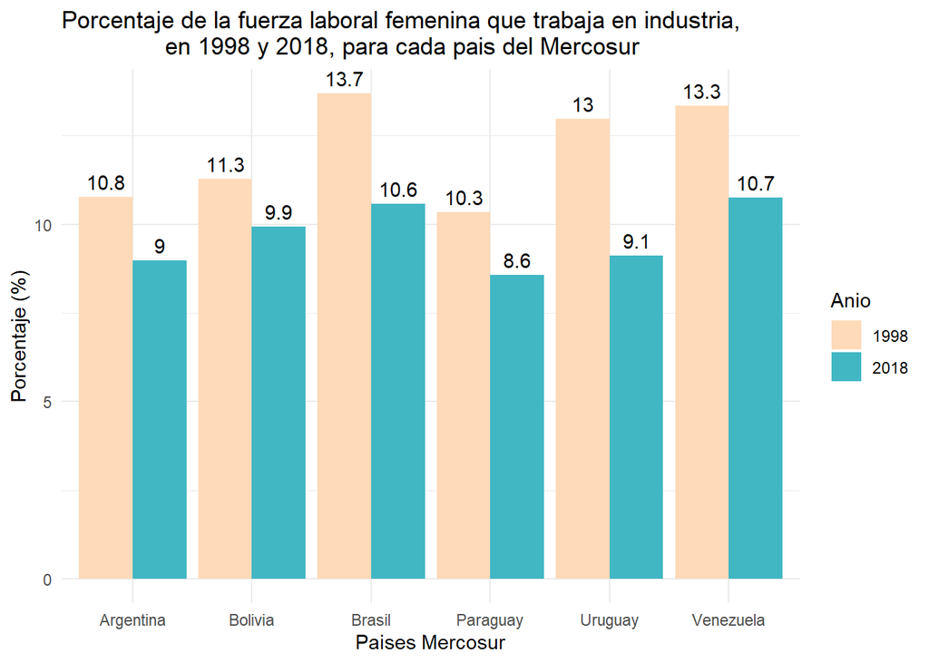

```r
industria_1998_2018 |>
mutate(Anio=as.character(Anio)) |>
ggplot(aes(x=pais_region,y=empleo_industria_mujeres, fill=Anio))+
  geom_col(position = "dodge") +
  scale_fill_manual(values = c("1998" = "#FFDAB9", "2018" = "#41B7C4")) +
   ggtitle ("Porcentaje de la fuerza laboral femenina que trabaja en industria,
               en 1998 y 2018, para cada pais del Mercosur") +
  labs(x = "Paises Mercosur",y = "Porcentaje (%)") +
  geom_text(aes(label = round(empleo_industria_mujeres, digits = 1)),
    position = position_dodge(0.9),
    vjust = -0.5) +
  theme_minimal()
```

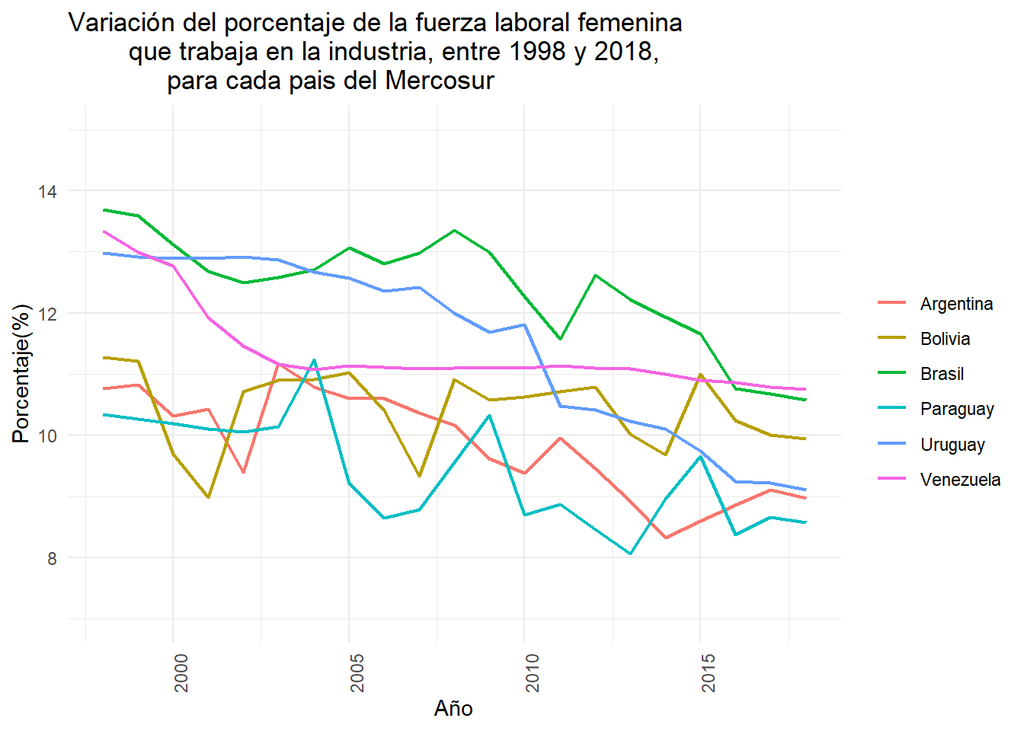

```r
ggplot(empleo_mercosur, aes(x = Anio, y = empleo_industria_mujeres, group = pais_region)) +
  geom_line (aes(colour = pais_region), size = 0.8)  +
    scale_y_continuous(limits= c(7, 15))+
  labs(title = "Variación del porcentaje de la fuerza laboral femenina
        que trabaja en la industria, entre 1998 y 2018,
             para cada pais del Mercosur",
       x = "Año",
       y = "Porcentaje(%)") +
theme_minimal() +
  theme (axis.text.x= element_text(  angle= 90, hjust= 1),
         legend.title = element_text(color ="white"))
```

*A su vez podemos ver como la participacion de mujeres disminuye en el sector industrial y aumenta en el sector servicios

```r
servicios_1998_2018 <- select(empleo_mercosur, pais_region, Anio, empleo_servicios_mujeres)|>
  filter(Anio == 1998 | Anio == 2018)
```

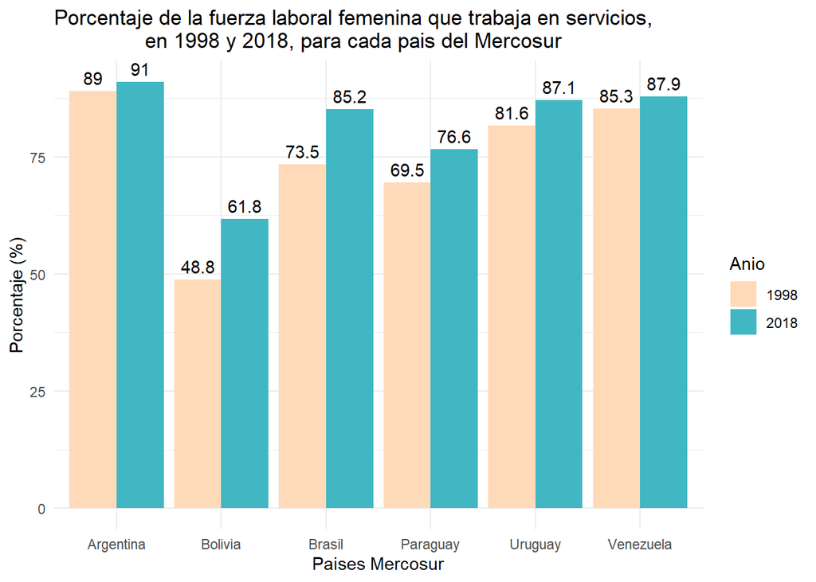

```r
servicios_1998_2018 |>
mutate(Anio=as.character(Anio)) |>
ggplot(aes(x=pais_region,y=empleo_servicios_mujeres, fill=Anio))+
  geom_col(position = "dodge") +
  scale_fill_manual(values = c("1998" = "#FFDAB9", "2018" = "#41B7C4")) +
  ggtitle ("Porcentaje de la fuerza laboral femenina que trabaja en servicios,
               en 1998 y 2018, para cada pais del Mercosur") +
  labs(x = "Paises Mercosur",y = "Porcentaje (%)") +
  geom_text(aes(label = round(empleo_servicios_mujeres, digits = 1)),
    position = position_dodge(0.9),
    vjust = -0.5) +
  theme_minimal()
```

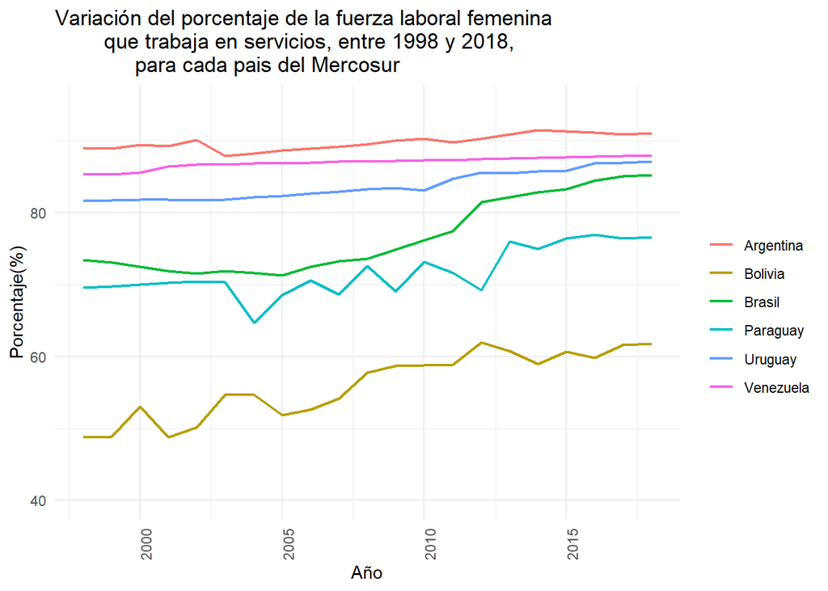

```r
ggplot(empleo_mercosur, aes(x = Anio, y = empleo_servicios_mujeres, group = pais_region)) +
  geom_line (aes(colour = pais_region), size = 0.8)  +
    scale_y_continuous(limits= c(40, 95))+
  labs(title = "Variación del porcentaje de la fuerza laboral femenina
        que trabaja en servicios, entre 1998 y 2018,
             para cada pais del Mercosur",
       x = "Año",
       y = "Porcentaje(%)") +
theme_minimal() +
  theme (axis.text.x= element_text(  angle= 90, hjust= 1),
         legend.title = element_text(color ="white"))
```